# PlantClassification

**1. Import the libraries, load dataset, print shape of data, visualize the images in dataset. (5 Marks)**

```python
%matplotlib inline
import numpy as np
import os
import pandas as pd
import seaborn as sns
from scipy import ndimage
import matplotlib.pyplot as plt
from sklearn.model_selection import train_test_split
from sklearn.metrics import confusion_matrix
from sklearn.preprocessing import OneHotEncoder, LabelEncoder, LabelBinarizer
from tensorflow import keras
from tensorflow.keras.models import Sequential
from tensorflow.keras.layers import Dense, Dropout, Activation, Flatten
from tensorflow.keras.layers import Conv2D, MaxPooling2D, BatchNormalization
```

```python
from google.colab import drive
drive.mount('/content/sample_data/aiml')
```

```python
labels = pd.read_csv('/content/sample_data/aiml/My Drive/AIML/Labels.csv')
labels.count()
```

```
Label    4750
dtype: int64
```

```python
labels.groupby('Label').count()
```

| Label |
| --- |
| Black-grass |
| Charlock |
| Cleavers |
| Common Chickweed |
| Common wheat |
| Fat Hen |
| Loose Silky-bent |
| Maize |
| Scentless Mayweed |
| Shepherds Purse |
| Small-flowered Cranesbill |
| Sugar beet |

```python
label_unique = labels.Label.unique()
label_unique
```

```
array(['Small-flowered Cranesbill', 'Fat Hen', 'Shepherds Purse',
       'Common wheat', 'Common Chickweed', 'Charlock', 'Cleavers',
       'Scentless Mayweed', 'Sugar beet', 'Maize', 'Black-grass',
       'Loose Silky-bent'], dtype=object)
```

```python
label_df = pd.DataFrame( label_unique, columns = ['plant_label'])
label_df
```

|  | plant_label |
| --- | --- |
| 0 | Small-flowered Cranesbill |
| 1 | Fat Hen |
| 2 | Shepherds Purse |
| 3 | Common wheat |
| 4 | Common Chickweed |
| 5 | Charlock |
| 6 | Cleavers |
| 7 | Scentless Mayweed |
| 8 | Sugar beet |
| 9 | Maize |
| 10 | Black-grass |
| 11 | Loose Silky-bent |

```python
images = np.load('/content/sample_data/aiml/My Drive/AIML/images.npy')
images.shape
```

```
(4750, 128, 128, 3)
```

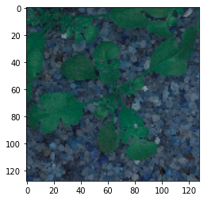

```python
#Visualize images in the dataset
plt.imshow(images[1200])
```

4750 images of 128x128 dimensions with RGB values

**2. Data Pre-processing: (15 Marks) a. Normalization. b. Gaussian Blurring. c. Visualize data after pre-processing.**

```python
#Normalizing
images_normalized = images/255
```

```python
#Guassian blurring
blurred_images = ndimage.gaussian_filter(images_normalized, sigma=3)
blurred_images.shape
```

```
(4750, 128, 128, 3)
```

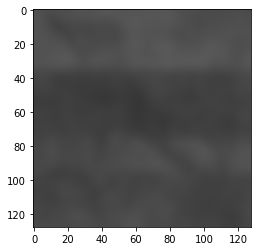

```python
#Visualizing data after preprocessing
plt.imshow(blurred_images[1200])
```

**3. Make data compatible: (10 Marks) a. Convert labels to one-hot-vectors. b. Print the label for y_train[0]. c. Split the dataset into training, testing, and validation set. (Hint: First split images and labels into training and testing set with test_size = 0.3. Then further split test data into test and validation set with test_size = 0.5) d. Check the shape of data, Reshape data into shapes compatible with Keras models if it’s not already. If it’s already in the compatible shape, then comment in the notebook that it’s already in compatible shape.**

```python
labelEncode = LabelBinarizer()
labelBinEncoded = labelEncode.fit_transform(labels)
```

```python
labelBinEncoded
```

```
array([[0, 0, 0, ..., 0, 1, 0],
       [0, 0, 0, ..., 0, 1, 0],
       [0, 0, 0, ..., 0, 1, 0],
       ...,
       [0, 0, 0, ..., 0, 0, 0],
       [0, 0, 0, ..., 0, 0, 0],
       [0, 0, 0, ..., 0, 0, 0]])
```

```python
x_train, x_test, y_train, y_test = train_test_split(blurred_images, labelBinEncoded, test_size = 0.3, random_state=0)
x_test, x_val, y_test, y_val   = train_test_split(x_test, y_test, test_size= 0.5, random_state=0)
```

```python
y_train[0]
```

```
array([1, 0, 0, 0, 0, 0, 0, 0, 0, 0, 0, 0])
```

```python
x_train.shape
```

```
(3325, 128, 128, 3)
```

```python
y_train.shape
```

```
(3325, 12)
```

```python
x_test.shape
```

```
(712, 128, 128, 3)
```

```python
y_test.shape
```

```
(712, 12)
```

```python
x_val.shape
```

```
(713, 128, 128, 3)
```

```python
y_val.shape
```

```
(713, 12)
```

Training data and labels are in compatible shapes.

**4. Building CNN: (15 Marks) a. Define layers. b. Set optimizer and loss function. (Use Adam optimizer and categorical crossentropy.)**

```python
model = Sequential()

model.add(Conv2D(filters=64, kernel_size=(5, 5), input_shape=(128, 128, 3), activation='relu'))
model.add(BatchNormalization(axis=3))
model.add(Conv2D(filters=64, kernel_size=(5, 5), activation='relu'))
model.add(MaxPooling2D((2, 2)))
model.add(BatchNormalization(axis=3))
model.add(Dropout(0.1))

model.add(Conv2D(filters=128, kernel_size=(5, 5), activation='relu'))
model.add(BatchNormalization(axis=3))
model.add(Conv2D(filters=128, kernel_size=(5, 5), activation='relu'))
model.add(MaxPooling2D((2, 2)))
model.add(BatchNormalization(axis=3))
model.add(Dropout(0.1))

model.add(Conv2D(filters=256, kernel_size=(5, 5), activation='relu'))
model.add(BatchNormalization(axis=3))
model.add(Conv2D(filters=256, kernel_size=(5, 5), activation='relu'))
model.add(MaxPooling2D((2, 2)))
model.add(BatchNormalization(axis=3))
model.add(Dropout(0.1))

model.add(Flatten())

model.add(Dense(256, activation='relu'))
model.add(BatchNormalization())
model.add(Dropout(0.5))

model.add(Dense(256, activation='relu'))
model.add(BatchNormalization())
model.add(Dropout(0.5))

model.add(Dense(12, activation='softmax'))
```

```python
opt = keras.optimizers.Adam(learning_rate=0.0001)
# compile model
model.compile(loss='categorical_crossentropy', optimizer=opt, metrics=['accuracy'])
```

```python
model.summary()
```

```
Model: "sequential_1"
_________________________________________________________________
Layer (type)                 Output Shape              Param #
=================================================================
conv2d (Conv2D)              (None, 124, 124, 64)      4864
_________________________________________________________________
batch_normalization (BatchNo (None, 124, 124, 64)      256
_________________________________________________________________
conv2d_1 (Conv2D)            (None, 120, 120, 64)      102464
_________________________________________________________________
max_pooling2d (MaxPooling2D) (None, 60, 60, 64)        0
_________________________________________________________________
batch_normalization_1 (Batch (None, 60, 60, 64)        256
_________________________________________________________________
dropout (Dropout)            (None, 60, 60, 64)        0
_________________________________________________________________
conv2d_2 (Conv2D)            (None, 56, 56, 128)       204928
_________________________________________________________________
batch_normalization_2 (Batch (None, 56, 56, 128)       512
_________________________________________________________________
conv2d_3 (Conv2D)            (None, 52, 52, 128)       409728
_________________________________________________________________
max_pooling2d_1 (MaxPooling2 (None, 26, 26, 128)       0
_________________________________________________________________
batch_normalization_3 (Batch (None, 26, 26, 128)       512
_________________________________________________________________
dropout_1 (Dropout)          (None, 26, 26, 128)       0
_________________________________________________________________
conv2d_4 (Conv2D)            (None, 22, 22, 256)       819456
_________________________________________________________________
batch_normalization_4 (Batch (None, 22, 22, 256)       1024
_________________________________________________________________
conv2d_5 (Conv2D)            (None, 18, 18, 256)       1638656
_________________________________________________________________
max_pooling2d_2 (MaxPooling2 (None, 9, 9, 256)         0
_________________________________________________________________
batch_normalization_5 (Batch (None, 9, 9, 256)         1024
_________________________________________________________________
dropout_2 (Dropout)          (None, 9, 9, 256)         0
_________________________________________________________________
flatten (Flatten)            (None, 20736)             0
_________________________________________________________________
dense (Dense)                (None, 256)               5308672
_________________________________________________________________
batch_normalization_6 (Batch (None, 256)               1024
_________________________________________________________________
dropout_3 (Dropout)          (None, 256)               0
_________________________________________________________________
dense_1 (Dense)              (None, 256)               65792
_________________________________________________________________
batch_normalization_7 (Batch (None, 256)               1024
_________________________________________________________________
dropout_4 (Dropout)          (None, 256)               0
_________________________________________________________________
dense_2 (Dense)              (None, 12)                3084
=================================================================
Total params: 8,563,276
Trainable params: 8,560,460
Non-trainable params: 2,816
_________________________________________________________________
```

**5. Fit and evaluate model and print confusion matrix. (10 Marks)**

```python
model.fit(x_train, y_train, batch_size=50, epochs=20, validation_data=(x_val, y_val), shuffle=True,  verbose=1)
```

```
<tensorflow.python.keras.callbacks.History at 0x7f0c597dda90>
```

```python
# Score trained model.
scores = model.evaluate(x_test, y_test, verbose=1)
print('Test loss:', scores[0])
print('Test accuracy:', scores[1])
```

```
Test loss: 0.03470199182629585
Test accuracy: 0.992977499961853
```

```python
y_pred = np.argmax(model.predict(x_test), axis=-1)
y_test_class = np.argmax(y_test, axis = 1)
y_pred.shape
```

```
(712,)
```

```python
confusionMTX = confusion_matrix(y_test_class, y_pred)
confusionMTX
```

```
array([[35,  0,  0,  0,  0,  0,  2,  0,  0,  0,  0,  0],
       [ 0, 50,  0,  0,  0,  0,  0,  0,  0,  0,  0,  0],
       [ 0,  0, 51,  0,  0,  0,  0,  0,  0,  0,  0,  0],
       [ 0,  0,  0, 95,  0,  0,  0,  0,  0,  0,  0,  0],
       [ 0,  0,  0,  0, 35,  0,  0,  0,  0,  0,  0,  0],
       [ 0,  0,  0,  0,  0, 85,  0,  0,  0,  0,  0,  0],
       [ 0,  0,  0,  0,  0,  0, 96,  0,  0,  0,  0,  0],
       [ 0,  0,  0,  0,  0,  0,  0, 26,  0,  0,  0,  0],
       [ 0,  0,  0,  0,  0,  0,  0,  0, 77,  0,  0,  0],
       [ 0,  0,  0,  0,  0,  1,  0,  0,  0, 39,  0,  0],
       [ 0,  0,  0,  0,  0,  0,  0,  0,  0,  0, 60,  0],
       [ 0,  0,  0,  1,  0,  0,  0,  0,  1,  0,  0, 58]])
```

**6. Visualize predictions for x_test[2], x_test[3], x_test[33], x_test[36], x_test[59]. (5 Marks)**

```
ID of the plant :  7
Name of the plant :Scentless Mayweed
Sample image and Actual Normalized, Guassian Blur Image of the plant
```

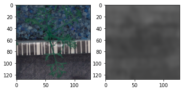

```python
#x_test[2]
print("ID of the plant : " , y_pred[2])
print("Name of the plant :" + label_df['plant_label'][y_pred[2]])
print("Sample image and Actual Normalized, Guassian Blur Image of the plant")
fig, ax = plt.subplots(1,2)
for i in range(4750):
  if (labels["Label"][i] == label_df['plant_label'][y_pred[2]]):
    ax[0].imshow(images[i])
    ax[1].imshow(x_test[2])
    exit
```

```
ID of the plant :  10
Name of the plant :Black-grass
Sample image and Actual Normalized, Guassian Blur Image of the plant
```

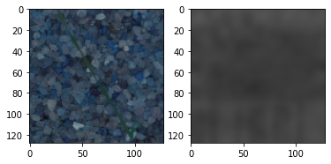

```python
#x_test[3]
print("ID of the plant : " , y_pred[3])
print("Name of the plant :" + label_df['plant_label'][y_pred[3]])
print("Sample image and Actual Normalized, Guassian Blur Image of the plant")
fig, ax = plt.subplots(1,2)
for i in range(4750):
  if (labels["Label"][i] == label_df['plant_label'][y_pred[3]]):
    ax[0].imshow(images[i])
    ax[1].imshow(x_test[3])
    exit
```

```
ID of the plant :  3
Name of the plant :Common wheat
Sample image and Actual Normalized, Guassian Blur Image of the plant
```

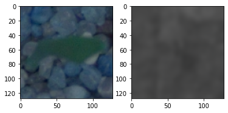

```python
#x_test[33]
print("ID of the plant : " , y_pred[33])
print("Name of the plant :" + label_df['plant_label'][y_pred[33]])
print("Sample image and Actual Normalized, Guassian Blur Image of the plant")
fig, ax = plt.subplots(1,2)
for i in range(4750):
  if (labels["Label"][i] == label_df['plant_label'][y_pred[33]]):
    ax[0].imshow(images[i])
    ax[1].imshow(x_test[33])
    exit
```

```
ID of the plant :  5
Name of the plant :Charlock
Sample image and Actual Normalized, Guassian Blur Image of the plant
```

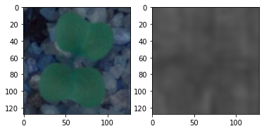

```python
#x_test[36]
print("ID of the plant : " , y_pred[36])
print("Name of the plant :" + label_df['plant_label'][y_pred[36]])
print("Sample image and Actual Normalized, Guassian Blur Image of the plant")
fig, ax = plt.subplots(1,2)
for i in range(4750):
  if (labels["Label"][i] == label_df['plant_label'][y_pred[36]]):
    ax[0].imshow(images[i])
    ax[1].imshow(x_test[36])
    exit
```

```
ID of the plant :  11
Name of the plant :Loose Silky-bent
Sample image and Actual Normalized, Guassian Blur Image of the plant
```

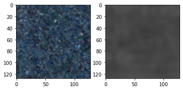

```python
x_test[59]
print("ID of the plant : " , y_pred[59])
print("Name of the plant :" + label_df['plant_label'][y_pred[59]])
print("Sample image and Actual Normalized, Guassian Blur Image of the plant")
fig, ax = plt.subplots(1,2)
for i in range(4750):
  if (labels["Label"][i] == label_df['plant_label'][y_pred[59]]):
    ax[0].imshow(images[i])
    ax[1].imshow(x_test[59])
    exit
```